# Investigate Player Attributes

#### DB Browser for SQLite was used in order to extract necessary tables from the database (in our case - Player_Attributes)

```python
import numpy as np
import pandas as pd
import matplotlib.pyplot as plt
import seaborn as sns
sns.set_style('darkgrid')
import warnings
warnings.simplefilter('ignore')
%matplotlib inline
```

```python
cd C:\Users\JPierson\Desktop\PythonFiles\Project2
```

```
C:\Users\JPierson\Desktop\PythonFiles\Project2
```

#### Main goal of the project is to prove that player attributes like potential, vision, positioning, reactions and stamina have significant impact on forming players' overall rating.

#### Assessing data and building intuition

```python
pd.set_option("max_columns", 1000)
pd.set_option("max_rows", 1000)
```

```python
player_attributes = pd.read_csv("Player_Attributes.csv")
```

```python
player_attributes.describe()
```

|  | id | player_fifa_api_id | player_api_id | overall_rating | potential | crossing | finishing | heading_accuracy | short_passing | volleys | dribbling | curve | free_kick_accuracy | long_passing | ball_control | acceleration | sprint_speed | agility | reactions | balance | shot_power | jumping | stamina | strength | long_shots | aggression | interceptions | positioning | vision | … |
| --- | --- | --- | --- | --- | --- | --- | --- | --- | --- | --- | --- | --- | --- | --- | --- | --- | --- | --- | --- | --- | --- | --- | --- | --- | --- | --- | --- | --- | --- | --- |
| count | 183978.00000 | 183978.000000 | 183978.000000 | 183142.000000 | 183142.000000 | 183142.000000 | 183142.000000 | 183142.000000 | 183142.000000 | 181265.000000 | 183142.000000 | 181265.000000 | 183142.000000 | 183142.000000 | 183142.000000 | 183142.000000 | 183142.000000 | 181265.000000 | 183142.000000 | 181265.000000 | 183142.000000 | 181265.000000 | 183142.000000 | 183142.000000 | 183142.000000 | 183142.000000 | 183142.000000 | 183142.000000 | 181265.000000 | … |
| mean | 91989.50000 | 165671.524291 | 135900.617324 | 68.600015 | 73.460353 | 55.086883 | 49.921078 | 57.266023 | 62.429672 | 49.468436 | 59.175154 | 52.965675 | 49.380950 | 57.069880 | 63.388879 | 67.659357 | 68.051244 | 65.970910 | 66.103706 | 65.189496 | 61.808427 | 66.969045 | 67.038544 | 67.424529 | 53.339431 | 60.948046 | 52.009271 | 55.786504 | 57.873550 | … |
| std | 53110.01825 | 53851.094769 | 136927.840510 | 7.041139 | 6.592271 | 17.242135 | 19.038705 | 16.488905 | 14.194068 | 18.256618 | 17.744688 | 18.255788 | 17.831746 | 14.394464 | 15.196671 | 12.983326 | 12.569721 | 12.954585 | 9.155408 | 13.063188 | 16.135143 | 11.006734 | 13.165262 | 12.072280 | 18.367025 | 16.089521 | 19.450133 | 18.448292 | 15.144086 | … |
| min | 1.00000 | 2.000000 | 2625.000000 | 33.000000 | 39.000000 | 1.000000 | 1.000000 | 1.000000 | 3.000000 | 1.000000 | 1.000000 | 2.000000 | 1.000000 | 3.000000 | 5.000000 | 10.000000 | 12.000000 | 11.000000 | 17.000000 | 12.000000 | 2.000000 | 14.000000 | 10.000000 | 10.000000 | 1.000000 | 6.000000 | 1.000000 | 2.000000 | 1.000000 | … |
| 25% | 45995.25000 | 155798.000000 | 34763.000000 | 64.000000 | 69.000000 | 45.000000 | 34.000000 | 49.000000 | 57.000000 | 35.000000 | 52.000000 | 41.000000 | 36.000000 | 49.000000 | 58.000000 | 61.000000 | 62.000000 | 58.000000 | 61.000000 | 58.000000 | 54.000000 | 60.000000 | 61.000000 | 60.000000 | 41.000000 | 51.000000 | 34.000000 | 45.000000 | 49.000000 | … |
| 50% | 91989.50000 | 183488.000000 | 77741.000000 | 69.000000 | 74.000000 | 59.000000 | 53.000000 | 60.000000 | 65.000000 | 52.000000 | 64.000000 | 56.000000 | 50.000000 | 59.000000 | 67.000000 | 69.000000 | 69.000000 | 68.000000 | 67.000000 | 67.000000 | 65.000000 | 68.000000 | 69.000000 | 69.000000 | 58.000000 | 64.000000 | 57.000000 | 60.000000 | 60.000000 | … |
| 75% | 137983.75000 | 199848.000000 | 191080.000000 | 73.000000 | 78.000000 | 68.000000 | 65.000000 | 68.000000 | 72.000000 | 64.000000 | 72.000000 | 67.000000 | 63.000000 | 67.000000 | 73.000000 | 77.000000 | 77.000000 | 75.000000 | 72.000000 | 74.000000 | 73.000000 | 74.000000 | 76.000000 | 76.000000 | 67.000000 | 73.000000 | 68.000000 | 69.000000 | 69.000000 | … |
| max | 183978.00000 | 234141.000000 | 750584.000000 | 94.000000 | 97.000000 | 95.000000 | 97.000000 | 98.000000 | 97.000000 | 93.000000 | 97.000000 | 94.000000 | 97.000000 | 97.000000 | 97.000000 | 97.000000 | 97.000000 | 96.000000 | 96.000000 | 96.000000 | 97.000000 | 96.000000 | 96.000000 | 96.000000 | 96.000000 | 97.000000 | 96.000000 | 96.000000 | 97.000000 | … |

```python
player_attributes.info()
```

```
<class 'pandas.core.frame.DataFrame'>
RangeIndex: 183978 entries, 0 to 183977
Data columns (total 42 columns):
 #   Column               Non-Null Count   Dtype
---  ------               --------------   -----
 0   id                   183978 non-null  int64
 1   player_fifa_api_id   183978 non-null  int64
 2   player_api_id        183978 non-null  int64
 3   date                 183978 non-null  object
 4   overall_rating       183142 non-null  float64
 5   potential            183142 non-null  float64
 6   preferred_foot       183142 non-null  object
 7   attacking_work_rate  180748 non-null  object
 8   defensive_work_rate  183142 non-null  object
 9   crossing             183142 non-null  float64
```

[output cut: 34 more lines]

```python
# check which columns have missing values with info()

player_attributes.isna().sum()
```

```
id                        0
player_fifa_api_id        0
player_api_id             0
date                      0
overall_rating          836
potential               836
preferred_foot          836
attacking_work_rate    3230
defensive_work_rate     836
crossing                836
finishing               836
heading_accuracy        836
short_passing           836
volleys                2713
dribbling               836
curve                  2713
free_kick_accuracy      836
long_passing            836
ball_control            836
acceleration            836
sprint_speed            836
agility                2713
reactions               836
balance                2713
shot_power              836
jumping                2713
stamina                 836
strength                836
long_shots              836
aggression              836
interceptions           836
positioning             836
vision                 2713
penalties               836
marking                 836
standing_tackle         836
sliding_tackle         2713
gk_diving               836
gk_handling             836
gk_kicking              836
gk_positioning          836
gk_reflexes             836
dtype: int64
```

#### Time for some cleaning job

```python
player_attributes.fillna(0, inplace=True)
```

```python
player_attributes_clean = player_attributes[player_attributes.loc[:]!=0].dropna()
```

```python
player_attributes_clean.to_csv('player_attributes_clean.csv', index=False)
```

#### Let's see what the data looks like now (after some cleaning was performed)

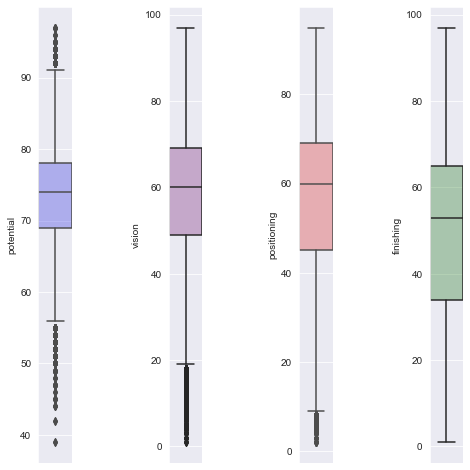

```python
# plot
def plotting_group_1():
    col = ['blue','purple','red','green']
    arr = ['potential','vision','positioning','finishing']
    fig, axarr = plt.subplots(1,4, figsize=(8,8))
    for i in range(len(arr)):
        ax = sns.boxplot(y=arr[i],hue=arr[i],data=player_attributes_clean, color=col[i],ax=axarr[i], width = 1.0)
        for patch in ax.artists:
            r, g, b, a = patch.get_facecolor()
            patch.set_facecolor((r, g, b, .3))
plotting_group_1()
plt.tight_layout(pad=6.0)
```

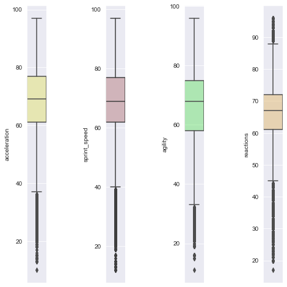

```python
def plotting_group_2():
    col = ['yellow','brown','lime','orange']
    arr = ['acceleration','sprint_speed','agility','reactions']
    fig, axarr = plt.subplots(1,4, figsize=(8,8))
    for i in range(len(arr)):
        ax = sns.boxplot(y=arr[i],hue=arr[i],data=player_attributes_clean, color=col[i],ax=axarr[i], width=1.0)
        for patch in ax.artists:
            r, g, b, a = patch.get_facecolor()
            patch.set_facecolor((r, g, b, .3))
plotting_group_2()
plt.tight_layout(pad=6.0)
```

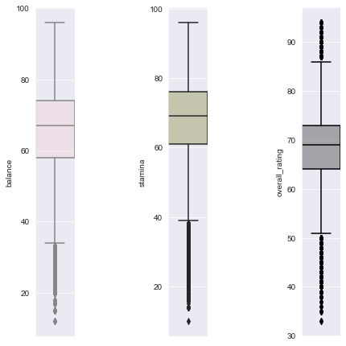

```python
def plotting_group_3():
    arr = ['balance','stamina','overall_rating']
    col = ['pink','olive','black']
    fig, axarr = plt.subplots(1,3, figsize=(8,8))
    for i in range(len(arr)):
        ax = sns.boxplot(y=arr[i],hue=arr[i],data=player_attributes_clean, color=col[i],ax=axarr[i], width=1.0)
        for patch in ax.artists:
            r, g, b, a = patch.get_facecolor()
            patch.set_facecolor((r, g, b, .3))
plotting_group_3()
plt.tight_layout(pad=8.0)
```

#### Boxplots show the presense of outliers in the dataset. Let's get rid of them and make the data even more cleaner.

```python
def cleaning_outliers():
    arr = ['potential','vision','positioning','finishing','acceleration','sprint_speed','agility','reactions','balance','stamina','overall_rating']
    for i in range(len(arr)):
        global player_attributes_clean
        q1, q3 = np.quantile(player_attributes_clean[arr[i]], [0.25, 0.75])
        iqr = q3 - q1
        lower_bound = q1 - (iqr * 1.5)
        upper_bound = q3 + (iqr * 1.5)
        player_attributes_clean = player_attributes_clean[player_attributes_clean[arr[i]]>lower_bound][player_attributes_clean[arr[i]]<upper_bound]

cleaning_outliers()
```

#### Let's have a look on what the distributions of the variables look like after cleaning the outliers

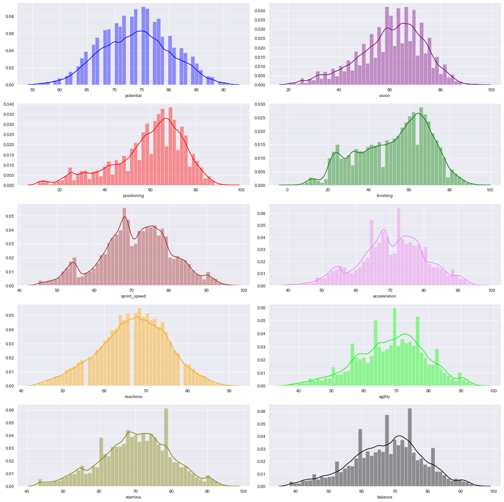

```python
# plot
fig, axarr = plt.subplots(5, 2)
fig.set_size_inches(16, 16)
sns.distplot(player_attributes_clean["potential"], color='blue',ax=axarr[0][0])
sns.distplot(player_attributes_clean["vision"], color="purple", ax=axarr[0][1])
sns.distplot(player_attributes_clean["positioning"], color="red",ax=axarr[1][0])
sns.distplot(player_attributes_clean["finishing"], color="green",ax=axarr[1][1])
sns.distplot(player_attributes_clean["acceleration"], color="violet",ax=axarr[2][1])
sns.distplot(player_attributes_clean["sprint_speed"], color="brown",ax=axarr[2][0])
sns.distplot(player_attributes_clean["agility"], color="lime",ax=axarr[3][1])
sns.distplot(player_attributes_clean["reactions"], color="orange",ax=axarr[3][0])
sns.distplot(player_attributes_clean["balance"], color="black",ax=axarr[4][1])
sns.distplot(player_attributes_clean["stamina"], color="olive",ax=axarr[4][0])

plt.tight_layout()
```

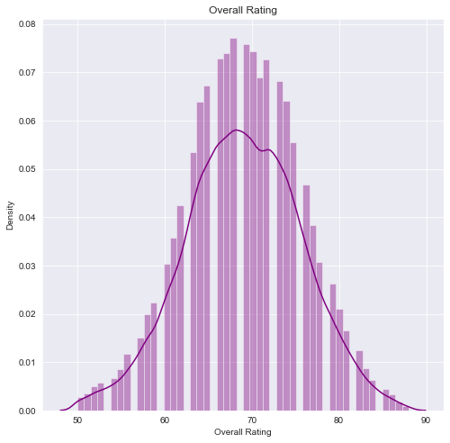

```python
fig, ax = plt.subplots()
fig.set_size_inches(8, 8)
sns.distplot(player_attributes_clean["overall_rating"], color="purple");
plt.title("Overall Rating");
plt.xlabel("Overall Rating");
plt.ylabel("Density");
```

#### Checking for the outliers again in order to make sure data is clean

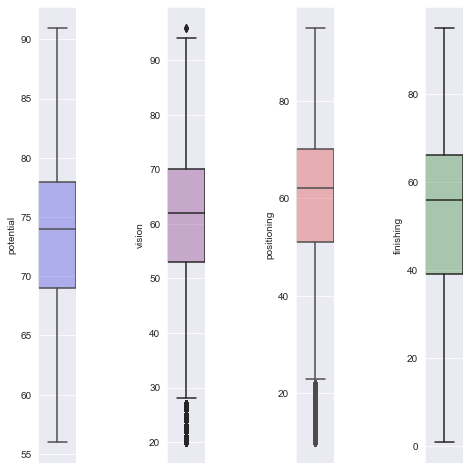

```python
plotting_group_1()
plt.tight_layout(pad=6.0)
```

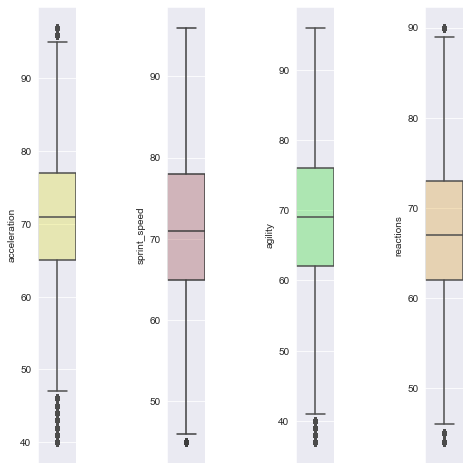

```python
plotting_group_2()
plt.tight_layout(pad=6.0)
```

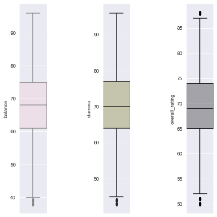

```python
plotting_group_3()
plt.tight_layout(pad=8.0)
```

#### Time to perform some analysis.

#### Next we’ll want to fit a linear regression model. We need to choose variables that we think we’ll be good predictors for the dependent variable — that can be done by checking the correlations between variables, by plotting the data and searching visually for relationship

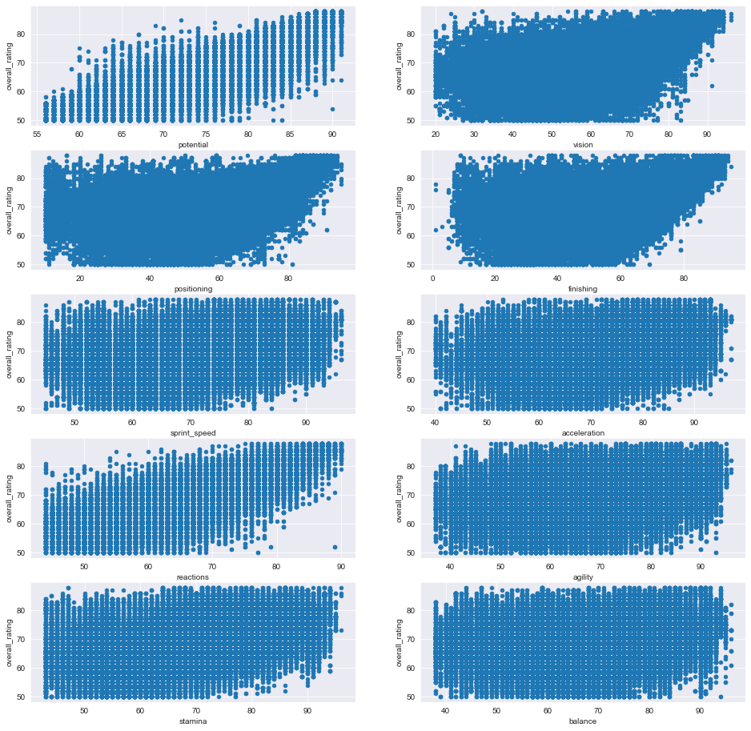

```python
fig, axarr = plt.subplots(5, 2, figsize=(16, 16))

player_attributes_clean.plot(x='potential',y='overall_rating',kind='scatter',ax=axarr[0][0])
player_attributes_clean.plot(x='vision',y='overall_rating',kind='scatter',ax=axarr[0][1])
player_attributes_clean.plot(x='positioning',y='overall_rating',kind='scatter',ax=axarr[1][0])
player_attributes_clean.plot(x='finishing',y='overall_rating',kind='scatter',ax=axarr[1][1])
player_attributes_clean.plot(x='acceleration',y='overall_rating',kind='scatter',ax=axarr[2][1])
player_attributes_clean.plot(x='sprint_speed',y='overall_rating',kind='scatter',ax=axarr[2][0])
player_attributes_clean.plot(x='agility',y='overall_rating',kind='scatter',ax=axarr[3][1])
player_attributes_clean.plot(x='reactions',y='overall_rating',kind='scatter',ax=axarr[3][0])
player_attributes_clean.plot(x='balance',y='overall_rating',kind='scatter',ax=axarr[4][1])
player_attributes_clean.plot(x='stamina',y='overall_rating',kind='scatter',ax=axarr[4][0])
```

#### Time to run multiple regression in order to identify how variables contribute to the players' overall rating

```python
import statsmodels.api as sm # import statsmodels

X = player_attributes_clean[["potential","vision","positioning","reactions","stamina"]] ## X usually means our input variables (or independent variables)
y = player_attributes_clean["overall_rating"] ## Y usually means our output/dependent variable
X = sm.add_constant(X) ## let's add an intercept (beta_0) to our model

# Note the difference in argument order
model = sm.OLS(y, X).fit() ## sm.OLS(output, input)
predictions = model.predict(X)

# Print out the statistics
model.summary()
```

OLS Regression Results

| Dep. Variable: | overall_rating | R-squared: | 0.765 |
| --- | --- | --- | --- |
| Model: | OLS | Adj. R-squared: | 0.765 |
| Method: | Least Squares | F-statistic: | 1.015e+05 |
| Date: | Sat, 17 Oct 2020 | Prob (F-statistic): | 0.00 |
| Time: | 15:13:19 | Log-Likelihood: | -4.0399e+05 |
| No. Observations: | 155973 | AIC: | 8.080e+05 |
| Df Residuals: | 155967 | BIC: | 8.081e+05 |
| Df Model: | 5 |  |  |
| Covariance Type: | nonrobust |  |  |

|  | coef | std err | t | P>\|t\| | [0.025 | 0.975] |
| --- | --- | --- | --- | --- | --- | --- |
| const | 4.2106 | 0.103 | 41.029 | 0.000 | 4.010 | 4.412 |
| potential | 0.4603 | 0.002 | 285.159 | 0.000 | 0.457 | 0.464 |
| vision | 0.0340 | 0.001 | 37.852 | 0.000 | 0.032 | 0.036 |
| positioning | 0.0043 | 0.001 | 6.118 | 0.000 | 0.003 | 0.006 |
| reactions | 0.3717 | 0.001 | 279.557 | 0.000 | 0.369 | 0.374 |
| stamina | 0.0512 | 0.001 | 55.822 | 0.000 | 0.049 | 0.053 |

| Omnibus: | 9011.401 | Durbin-Watson: | 0.399 |
| --- | --- | --- | --- |
| Prob(Omnibus): | 0.000 | Jarque-Bera (JB): | 16197.020 |
| Skew: | -0.445 | Prob(JB): | 0.00 |
| Kurtosis: | 4.304 | Cond. No. | 1.88e+03 |

Warnings:  
[1] Standard Errors assume that the covariance matrix of the errors is correctly specified.  
[2] The condition number is large, 1.88e+03. This might indicate that there are  
strong multicollinearity or other numerical problems.

#### Limitations of the project:

#### Dataset brings together the attributes of tens of thousands of soccer players but we are not sure if the data provided is complete,

#### correct and up to date. Additionally, dropping the rows with missing values (zero values in our case) also affected the overall

#### analysis. And finally, the condition number in the results of multiple regression is large, this might indicate that there are strong

#### multicollinearity or other numerical problems.